# Airline passenger satisfaction

## 2.1 Data cleaning and transformation

In this section, we clean up the dataset by removing unnecessary data and missing values. Then we process the satisfaction in the most useful way for our objective.

Remove usefull column of the dataset

```r
data<- data %>% select(-ID)
head(data)
```

```
##   Gender Age Customer.Type Type.of.Travel    Class Flight.Distance
## 1   Male  48    First-time       Business Business             821
## 2 Female  35     Returning       Business Business             821
## 3   Male  41     Returning       Business Business             853
## 4   Male  50     Returning       Business Business            1905
## 5 Female  49     Returning       Business Business            3470
## 6   Male  43     Returning       Business Business            3788
##   Departure.Delay Arrival.Delay Departure.and.Arrival.Time.Convenience
## 1               2             5                                      3
## 2              26            39                                      2
## 3               0             0                                      4
## 4               0             0                                      2
## 5               0             1                                      3
## 6               0             0                                      4
##   Ease.of.Online.Booking Check.in.Service Online.Boarding Gate.Location
```

[output cut: 27 more lines]

Remove observations with missing values

```r
data <- na.omit(data)
dimension_data <- dim(data)
dimension_data
```

```
## [1] 129487     23
```

I transform satisfaction into binary value 0 and 1:

- 0 = neutral or dissatisfied.
- 1 = satisfied.

```r
data$Satisfaction <- ifelse(data$Satisfaction %in% c("Neutral or Dissatisfied"),0, ifelse(data$Satisfaction %in% c("Satisfied"),1, data$Satisfaction))
data$Satisfaction <- as.factor(data$Satisfaction)
head(data)
```

```
##   Gender Age Customer.Type Type.of.Travel    Class Flight.Distance
## 1   Male  48    First-time       Business Business             821
## 2 Female  35     Returning       Business Business             821
## 3   Male  41     Returning       Business Business             853
## 4   Male  50     Returning       Business Business            1905
## 5 Female  49     Returning       Business Business            3470
## 6   Male  43     Returning       Business Business            3788
##   Departure.Delay Arrival.Delay Departure.and.Arrival.Time.Convenience
## 1               2             5                                      3
## 2              26            39                                      2
## 3               0             0                                      4
## 4               0             0                                      2
## 5               0             1                                      3
## 6               0             0                                      4
##   Ease.of.Online.Booking Check.in.Service Online.Boarding Gate.Location
```

[output cut: 27 more lines]

The two categories Departure delay and Arrival delay are highly collinear, so I create a new category Delay which is an average between the two. I then delete the two categories that are no longer needed.

```r
data <- data %>%
  mutate(Delay = (Departure.Delay + Arrival.Delay) / 2) %>%
  select(-Departure.Delay, -Arrival.Delay)
```

```r
data <- data %>% mutate_if(is.character, as.factor)
summary(data)
```

```
##     Gender           Age           Customer.Type     Type.of.Travel
##  Female:65703   Min.   : 7.00   First-time: 23714   Business:89445
##  Male  :63784   1st Qu.:27.00   Returning :105773   Personal:40042
##                 Median :40.00
##                 Mean   :39.43
##                 3rd Qu.:51.00
##                 Max.   :85.00
##           Class       Flight.Distance Departure.and.Arrival.Time.Convenience
##  Business    :61990   Min.   :  31    Min.   :0.000
##  Economy     :58117   1st Qu.: 414    1st Qu.:2.000
##  Economy Plus: 9380   Median : 844    Median :3.000
##                       Mean   :1190    Mean   :3.057
##                       3rd Qu.:1744    3rd Qu.:4.000
##                       Max.   :4983    Max.   :5.000
##  Ease.of.Online.Booking Check.in.Service Online.Boarding Gate.Location
##  Min.   :0.000          Min.   :0.000    Min.   :0.000   Min.   :0.000
##  1st Qu.:2.000          1st Qu.:3.000    1st Qu.:2.000   1st Qu.:2.000
##  Median :3.000          Median :3.000    Median :3.000   Median :3.000
##  Mean   :2.757          Mean   :3.306    Mean   :3.253   Mean   :2.977
##  3rd Qu.:4.000          3rd Qu.:4.000    3rd Qu.:4.000   3rd Qu.:4.000
##  Max.   :5.000          Max.   :5.000    Max.   :5.000   Max.   :5.000
##  On.board.Service  Seat.Comfort   Leg.Room.Service  Cleanliness
##  Min.   :0.000    Min.   :0.000   Min.   :0.000    Min.   :0.000
##  1st Qu.:2.000    1st Qu.:2.000   1st Qu.:2.000    1st Qu.:2.000
##  Median :4.000    Median :4.000   Median :4.000    Median :3.000
##  Mean   :3.383    Mean   :3.442   Mean   :3.351    Mean   :3.286
##  3rd Qu.:4.000    3rd Qu.:5.000   3rd Qu.:4.000    3rd Qu.:4.000
##  Max.   :5.000    Max.   :5.000   Max.   :5.000    Max.   :5.000
##  Food.and.Drink  In.flight.Service In.flight.Wifi.Service
##  Min.   :0.000   Min.   :0.000     Min.   :0.000
##  1st Qu.:2.000   1st Qu.:3.000     1st Qu.:2.000
##  Median :3.000   Median :4.000     Median :3.000
##  Mean   :3.205   Mean   :3.642     Mean   :2.729
##  3rd Qu.:4.000   3rd Qu.:5.000     3rd Qu.:4.000
##  Max.   :5.000   Max.   :5.000     Max.   :5.000
##  In.flight.Entertainment Baggage.Handling Satisfaction     Delay
##  Min.   :0.000           Min.   :1.000    0:73225      Min.   :   0.00
##  1st Qu.:2.000           1st Qu.:3.000    1:56262      1st Qu.:   0.00
##  Median :4.000           Median :4.000                 Median :   1.00
##  Mean   :3.358           Mean   :3.632                 Mean   :  14.87
##  3rd Qu.:4.000           3rd Qu.:5.000                 3rd Qu.:  12.00
##  Max.   :5.000           Max.   :5.000                 Max.   :1588.00
```

```r
print(dfSummary(data), method = 'render')
```

Data Frame Summary

data

**Dimensions**: 129487 x 22  
**Duplicates**: 0

| **No** | **Variable** | **Stats / Values** | **Freqs (% of Valid)** | **Graph** | **Valid** | **Missing** |
| --- | --- | --- | --- | --- | --- | --- |
| 1 | Gender [factor] | 1. Female 2. Male | 65703 ( 50.7% ) 63784 ( 49.3% ) |  | 129487 (100.0%) | 0 (0.0%) |
| 2 | Age [integer] | Mean (sd) : 39.4 (15.1) min ≤ med ≤ max: 7 ≤ 40 ≤ 85 IQR (CV) : 24 (0.4) | 75 distinct values |  | 129487 (100.0%) | 0 (0.0%) |
| 3 | Customer.Type [factor] | 1. First-time 2. Returning | 23714 ( 18.3% ) 105773 ( 81.7% ) |  | 129487 (100.0%) | 0 (0.0%) |
| 4 | Type.of.Travel [factor] | 1. Business 2. Personal | 89445 ( 69.1% ) 40042 ( 30.9% ) |  | 129487 (100.0%) | 0 (0.0%) |
| 5 | Class [factor] | 1. Business 2. Economy 3. Economy Plus | 61990 ( 47.9% ) 58117 ( 44.9% ) 9380 ( 7.2% ) |  | 129487 (100.0%) | 0 (0.0%) |
| 6 | Flight.Distance [integer] | Mean (sd) : 1190.2 (997.6) min ≤ med ≤ max: 31 ≤ 844 ≤ 4983 IQR (CV) : 1330 (0.8) | 3821 distinct values |  | 129487 (100.0%) | 0 (0.0%) |
| 7 | Departure.and.Arrival.Time.Convenience [integer] | Mean (sd) : 3.1 (1.5) min ≤ med ≤ max: 0 ≤ 3 ≤ 5 IQR (CV) : 2 (0.5) | 0 : 6664 ( 5.1% ) 1 : 19351 ( 14.9% ) 2 : 21478 ( 16.6% ) 3 : 22302 ( 17.2% ) 4 : 31786 ( 24.5% ) 5 : 27906 ( 21.6% ) |  | 129487 (100.0%) | 0 (0.0%) |
| 8 | Ease.of.Online.Booking [integer] | Mean (sd) : 2.8 (1.4) min ≤ med ≤ max: 0 ≤ 3 ≤ 5 IQR (CV) : 2 (0.5) | 0 : 5666 ( 4.4% ) 1 : 21808 ( 16.8% ) 2 : 29983 ( 23.2% ) 3 : 30297 ( 23.4% ) 4 : 24362 ( 18.8% ) 5 : 17371 ( 13.4% ) |  | 129487 (100.0%) | 0 (0.0%) |
| 9 | Check.in.Service [integer] | Mean (sd) : 3.3 (1.3) min ≤ med ≤ max: 0 ≤ 3 ≤ 5 IQR (CV) : 1 (0.4) | 0 : 1 ( 0.0% ) 1 : 16058 ( 12.4% ) 2 : 16056 ( 12.4% ) 3 : 35343 ( 27.3% ) 4 : 36229 ( 28.0% ) 5 : 25800 ( 19.9% ) |  | 129487 (100.0%) | 0 (0.0%) |
| 10 | Online.Boarding [integer] | Mean (sd) : 3.3 (1.4) min ≤ med ≤ max: 0 ≤ 3 ≤ 5 IQR (CV) : 2 (0.4) | 0 : 3071 ( 2.4% ) 1 : 13216 ( 10.2% ) 2 : 21866 ( 16.9% ) 3 : 27040 ( 20.9% ) 4 : 38353 ( 29.6% ) 5 : 25941 ( 20.0% ) |  | 129487 (100.0%) | 0 (0.0%) |
| 11 | Gate.Location [integer] | Mean (sd) : 3 (1.3) min ≤ med ≤ max: 0 ≤ 3 ≤ 5 IQR (CV) : 2 (0.4) | 0 : 1 ( 0.0% ) 1 : 21926 ( 16.9% ) 2 : 24219 ( 18.7% ) 3 : 35611 ( 27.5% ) 4 : 30376 ( 23.5% ) 5 : 17354 ( 13.4% ) |  | 129487 (100.0%) | 0 (0.0%) |
| 12 | On.board.Service [integer] | Mean (sd) : 3.4 (1.3) min ≤ med ≤ max: 0 ≤ 4 ≤ 5 IQR (CV) : 2 (0.4) | 0 : 5 ( 0.0% ) 1 : 14738 ( 11.4% ) 2 : 18290 ( 14.1% ) 3 : 28460 ( 22.0% ) 4 : 38587 ( 29.8% ) 5 : 29407 ( 22.7% ) |  | 129487 (100.0%) | 0 (0.0%) |
| 13 | Seat.Comfort [integer] | Mean (sd) : 3.4 (1.3) min ≤ med ≤ max: 0 ≤ 4 ≤ 5 IQR (CV) : 3 (0.4) | 0 : 1 ( 0.0% ) 1 : 15059 ( 11.6% ) 2 : 18462 ( 14.3% ) 3 : 23258 ( 18.0% ) 4 : 39651 ( 30.6% ) 5 : 33056 ( 25.5% ) |  | 129487 (100.0%) | 0 (0.0%) |
| 14 | Leg.Room.Service [integer] | Mean (sd) : 3.4 (1.3) min ≤ med ≤ max: 0 ≤ 4 ≤ 5 IQR (CV) : 2 (0.4) | 0 : 596 ( 0.5% ) 1 : 12846 ( 9.9% ) 2 : 24469 ( 18.9% ) 3 : 24982 ( 19.3% ) 4 : 35779 ( 27.6% ) 5 : 30815 ( 23.8% ) |  | 129487 (100.0%) | 0 (0.0%) |
| 15 | Cleanliness [integer] | Mean (sd) : 3.3 (1.3) min ≤ med ≤ max: 0 ≤ 3 ≤ 5 IQR (CV) : 2 (0.4) | 0 : 14 ( 0.0% ) 1 : 16680 ( 12.9% ) 2 : 20049 ( 15.5% ) 3 : 30552 ( 23.6% ) 4 : 33871 ( 26.2% ) 5 : 28321 ( 21.9% ) |  | 129487 (100.0%) | 0 (0.0%) |
| 16 | Food.and.Drink [integer] | Mean (sd) : 3.2 (1.3) min ≤ med ≤ max: 0 ≤ 3 ≤ 5 IQR (CV) : 2 (0.4) | 0 : 130 ( 0.1% ) 1 : 16010 ( 12.4% ) 2 : 27293 ( 21.1% ) 3 : 27712 ( 21.4% ) 4 : 30477 ( 23.5% ) 5 : 27865 ( 21.5% ) |  | 129487 (100.0%) | 0 (0.0%) |
| 17 | In.flight.Service [integer] | Mean (sd) : 3.6 (1.2) min ≤ med ≤ max: 0 ≤ 4 ≤ 5 IQR (CV) : 2 (0.3) | 0 : 5 ( 0.0% ) 1 : 8838 ( 6.8% ) 2 : 14252 ( 11.0% ) 3 : 25232 ( 19.5% ) 4 : 47198 ( 36.4% ) 5 : 33962 ( 26.2% ) |  | 129487 (100.0%) | 0 (0.0%) |
| 18 | In.flight.Wifi.Service [integer] | Mean (sd) : 2.7 (1.3) min ≤ med ≤ max: 0 ≤ 3 ≤ 5 IQR (CV) : 2 (0.5) | 0 : 3908 ( 3.0% ) 1 : 22250 ( 17.2% ) 2 : 32236 ( 24.9% ) 3 : 32087 ( 24.8% ) 4 : 24702 ( 19.1% ) 5 : 14304 ( 11.0% ) |  | 129487 (100.0%) | 0 (0.0%) |
| 19 | In.flight.Entertainment [integer] | Mean (sd) : 3.4 (1.3) min ≤ med ≤ max: 0 ≤ 4 ≤ 5 IQR (CV) : 2 (0.4) | 0 : 18 ( 0.0% ) 1 : 15634 ( 12.1% ) 2 : 21897 ( 16.9% ) 3 : 23805 ( 18.4% ) 4 : 36682 ( 28.3% ) 5 : 31451 ( 24.3% ) |  | 129487 (100.0%) | 0 (0.0%) |
| 20 | Baggage.Handling [integer] | Mean (sd) : 3.6 (1.2) min ≤ med ≤ max: 1 ≤ 4 ≤ 5 IQR (CV) : 2 (0.3) | 1 : 9008 ( 7.0% ) 2 : 14316 ( 11.1% ) 3 : 25771 ( 19.9% ) 4 : 46631 ( 36.0% ) 5 : 33761 ( 26.1% ) |  | 129487 (100.0%) | 0 (0.0%) |
| 21 | Satisfaction [factor] | 1. 0 2. 1 | 73225 ( 56.6% ) 56262 ( 43.4% ) |  | 129487 (100.0%) | 0 (0.0%) |
| 22 | Delay [numeric] | Mean (sd) : 14.9 (37.9) min ≤ med ≤ max: 0 ≤ 1 ≤ 1588 IQR (CV) : 12 (2.5) | 805 distinct values |  | 129487 (100.0%) | 0 (0.0%) |

Generated by summarytools 1.0.1 ([R](https://www.r-project.org/) version 4.4.1)  
2024-08-15

## 2.2 Dataset division

Split the dataset into train and test set.

```r
split <- partition_data(data, target_var = "Satisfaction", train_ratio = 0.8, seed = 123)

dim(split$trainX)
```

```
## [1] 103612     21
```

```r
dim(split$testX)
```

```
## [1] 25875    21
```

```r
train <- split$train
test <- split$test
testX <- split$testX
testy <- split$testY

trainY1 <- train[, "Satisfaction"]
testY1 <- test[, "Satisfaction"]
trainX <- train[, -which(names(train) == "Satisfaction")]
testX <- test[, -which(names(test) == "Satisfaction")]
```

# 3 Analysis of data

In this section, I analyse the characteristics of the dataset to find the most important features for calculating the satisfaction.

## 3.1 Correlation matrix

I transform the categorical variables of the dataframe into dummy variables, calculate the correlation matrix of the transformed variables and then display this correlation matrix. Categorical variables are transformed into dummy variables, where each unique category becomes a new column with values 0 or 1.

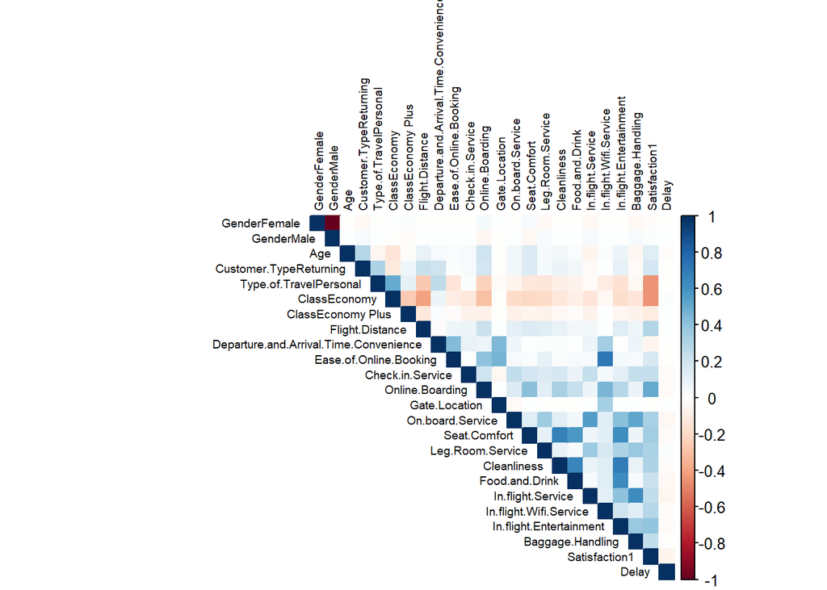

All categorial varibles are composed of two results, so they are converted with 0 or 1. The Class category, on the other hand, is divided into 2 categories as it is composed of 3 possible results.

We can analyse the table by interpreting the values approaching blue as positive classes, i.e. improving customer satisfaction, and in red all the categories that can make a passenger dissatisfied.

## 3.2 Plots satisfaction percentage

Taking the most important categories from the correlation matrix, I go to analyse them separately to see the percentage of satisfaction linked to each category.

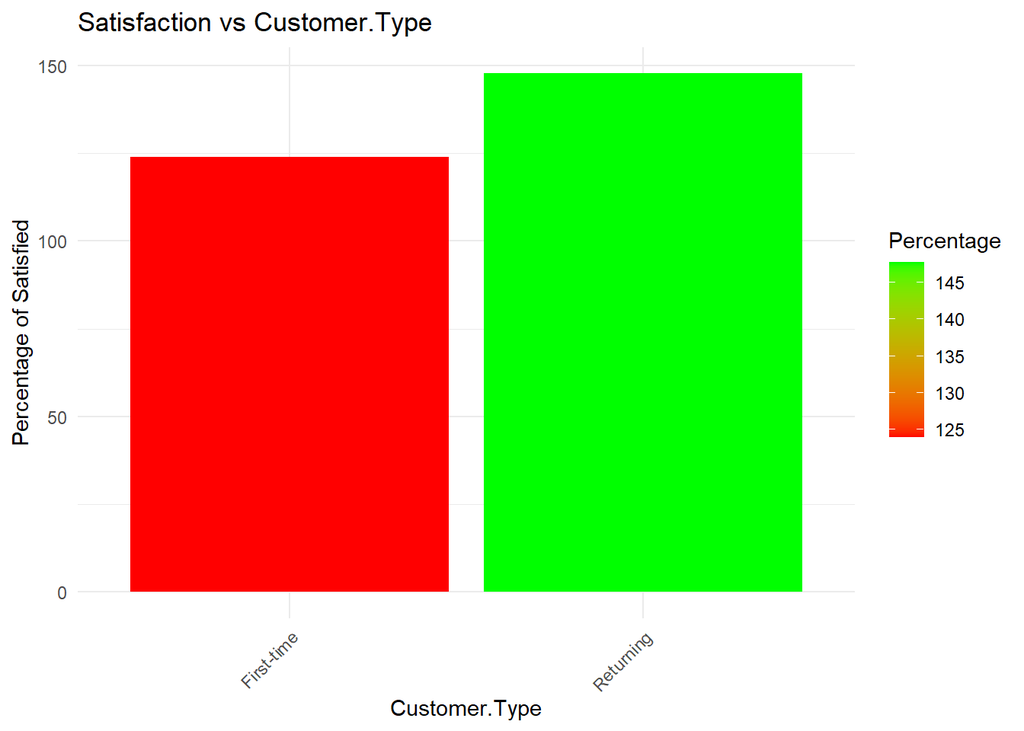

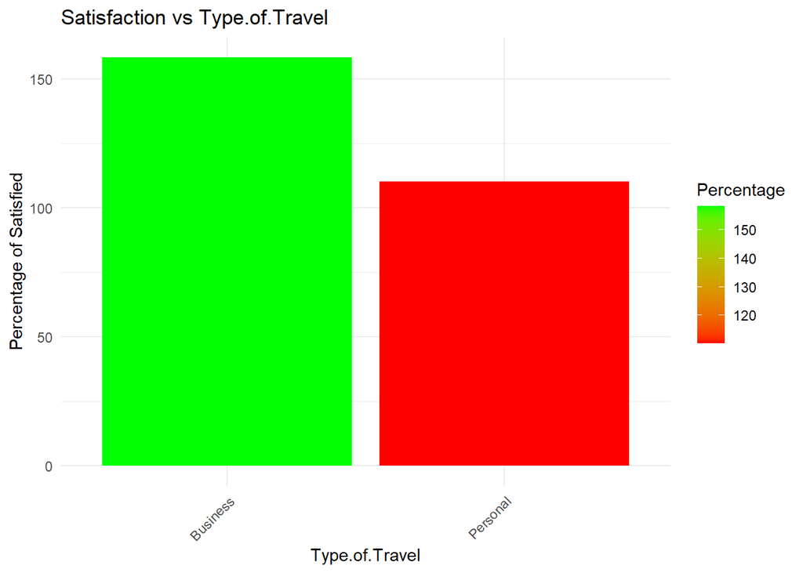

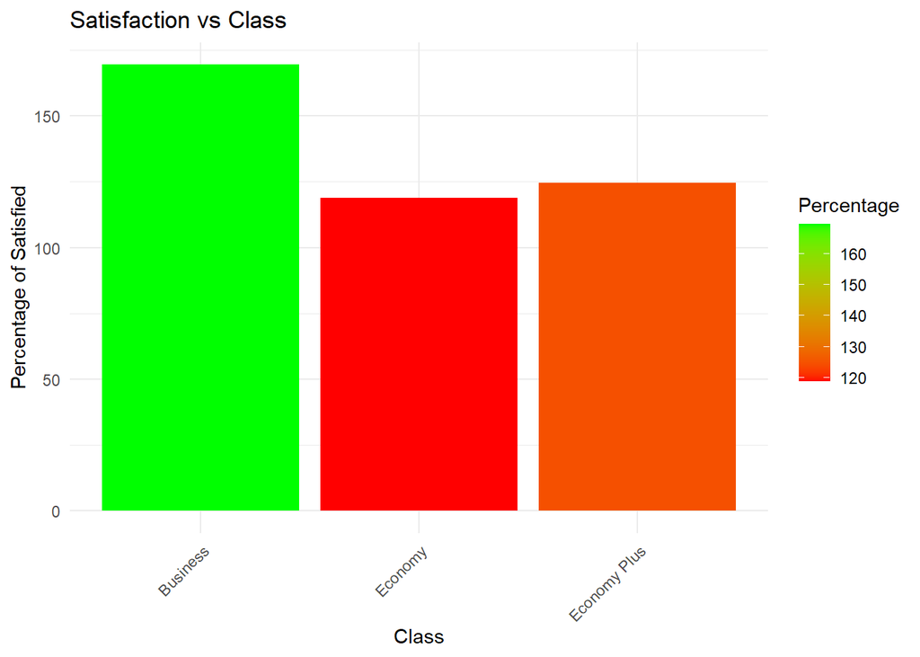

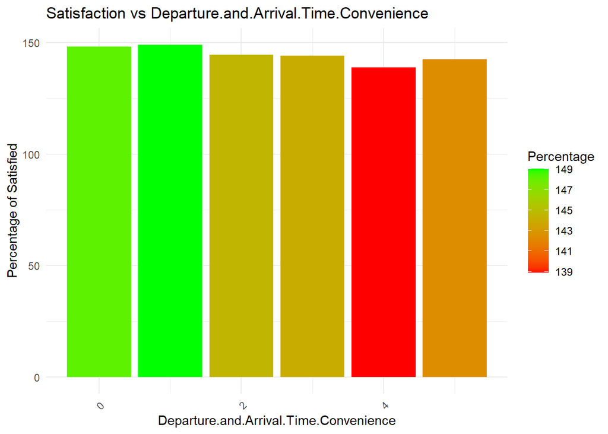

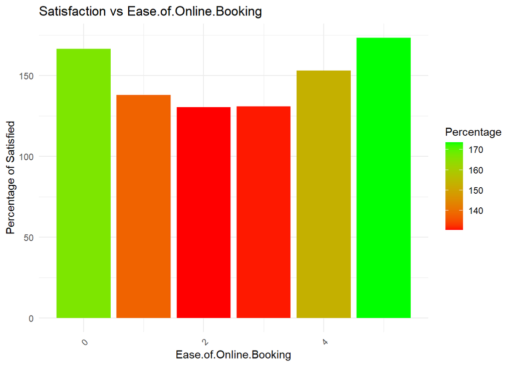

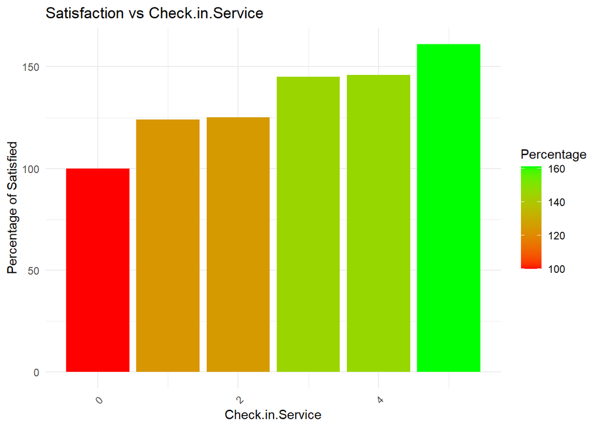

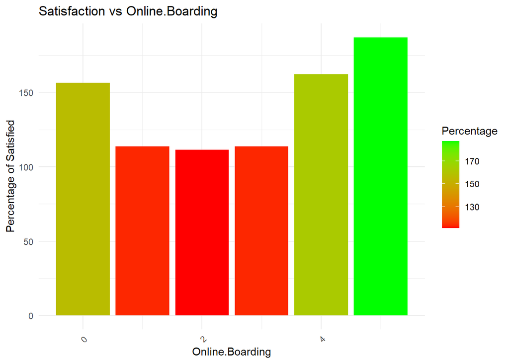

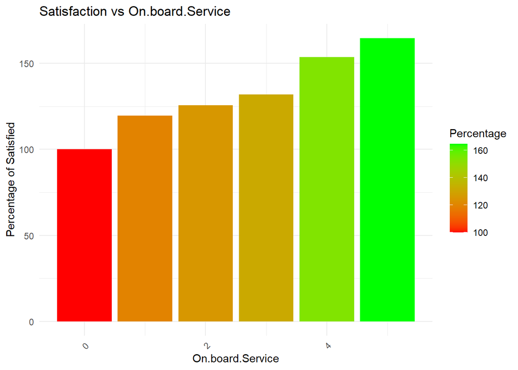

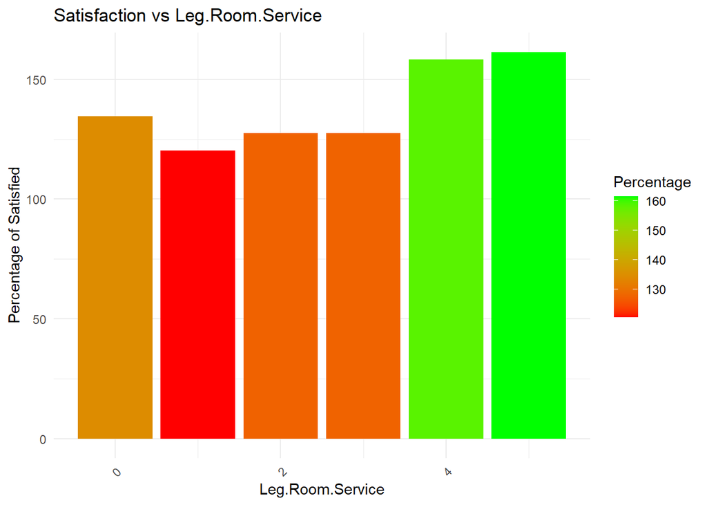

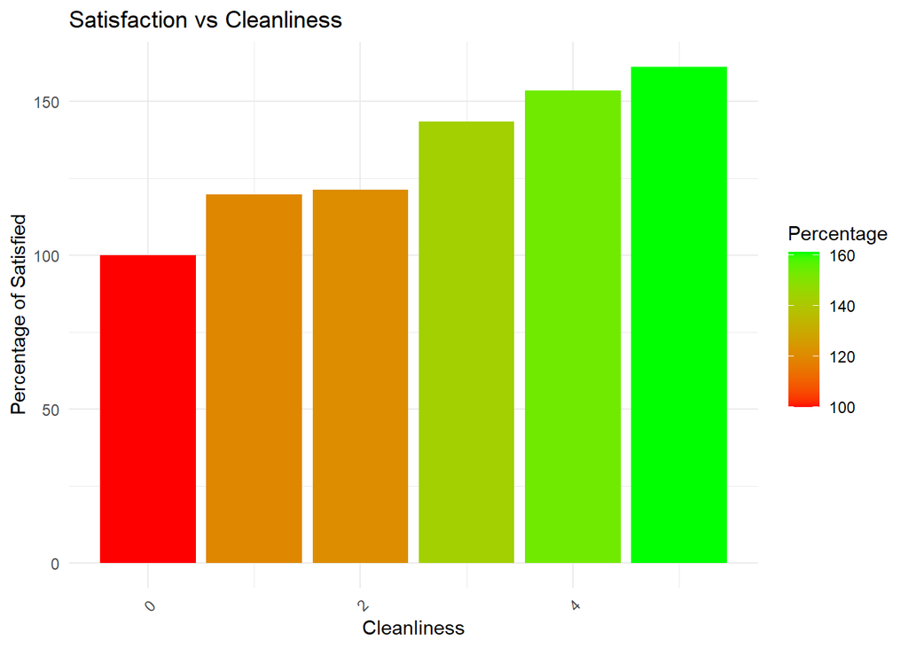

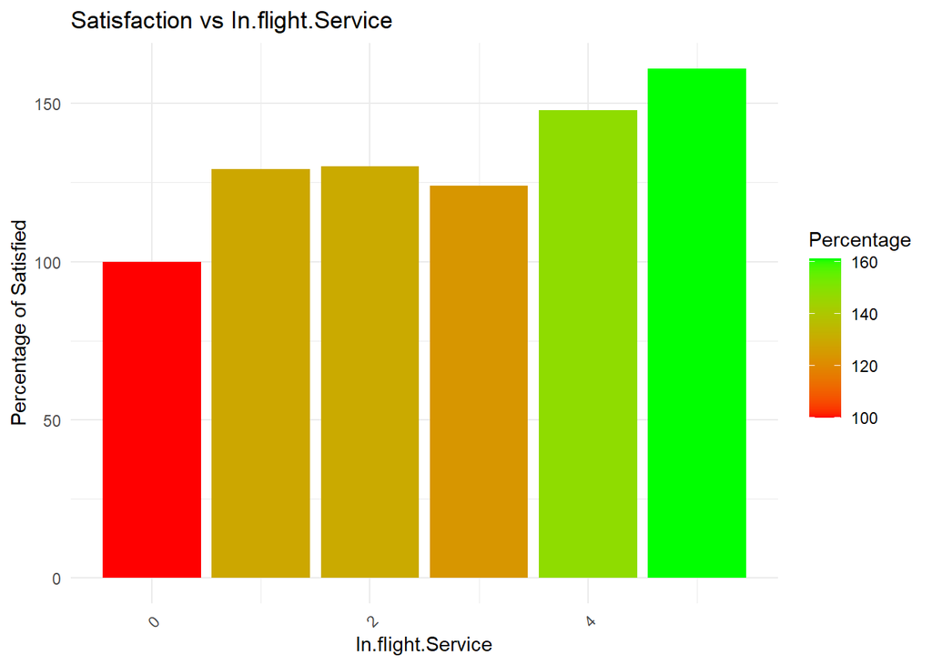

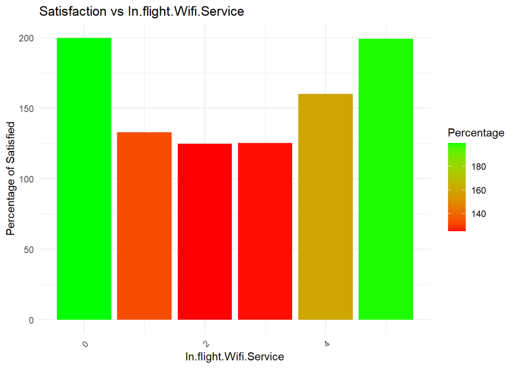

[1 more figures not shown]

## 3.3 Plots satisfied vs dissatisfied

Below, using the same categories, we look the differences between the number of satisfied and dissatisfied passengers.

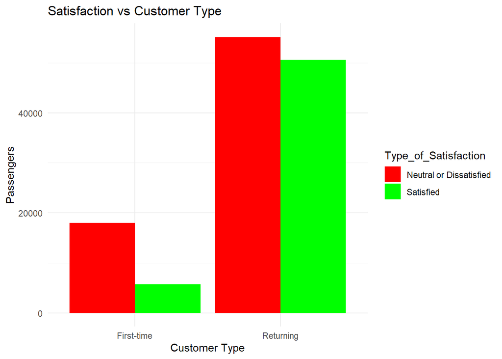

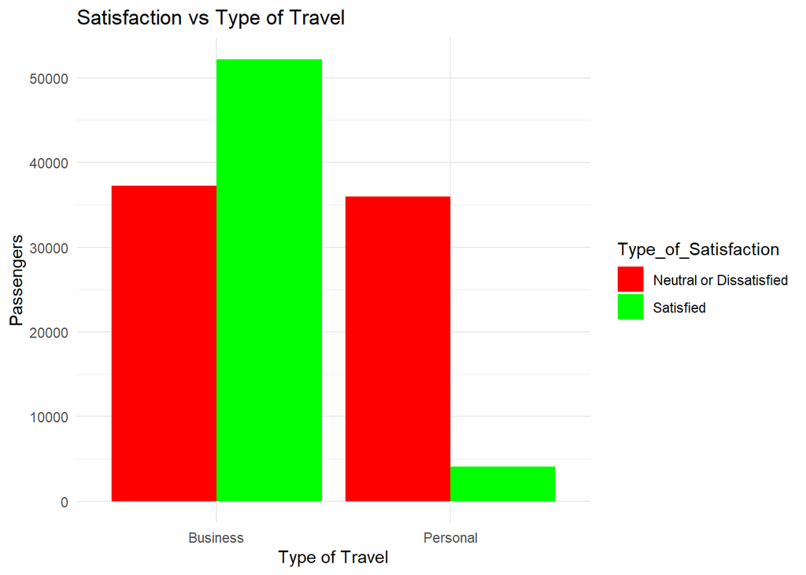

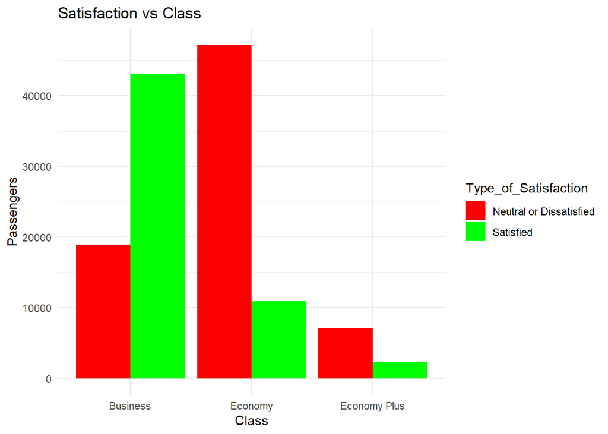

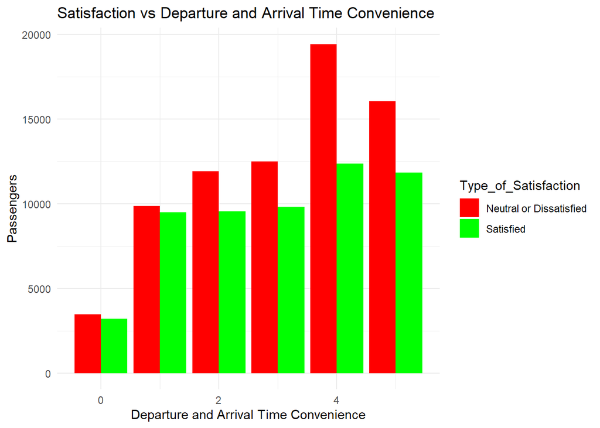

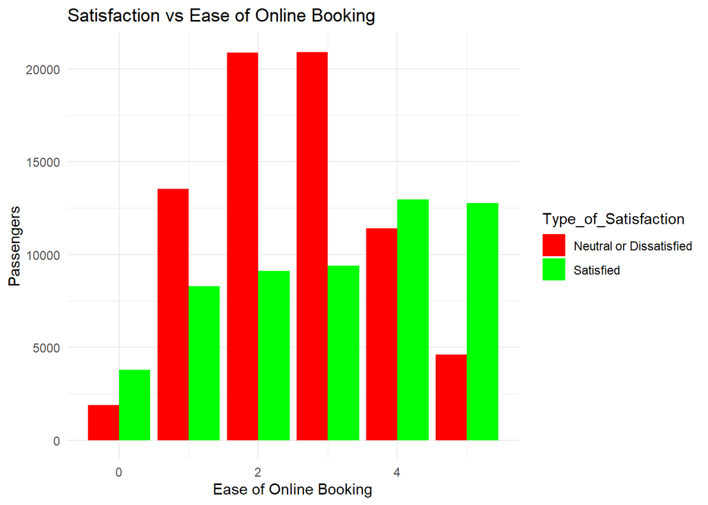

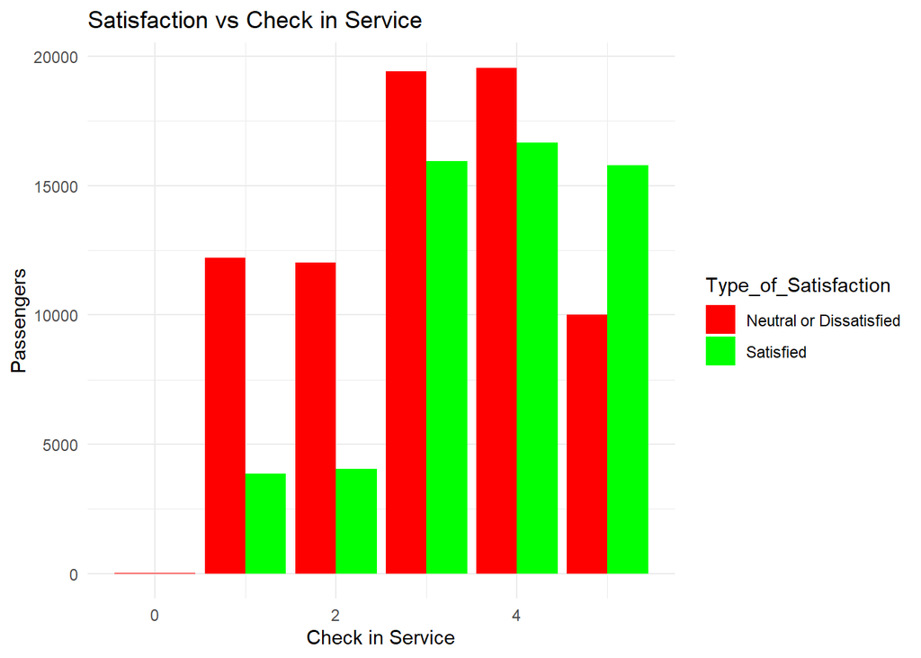

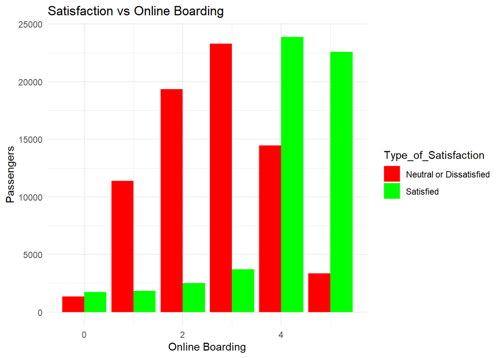

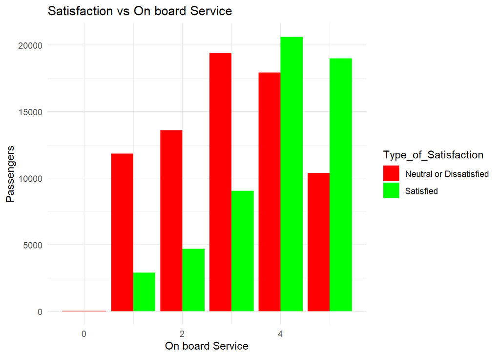

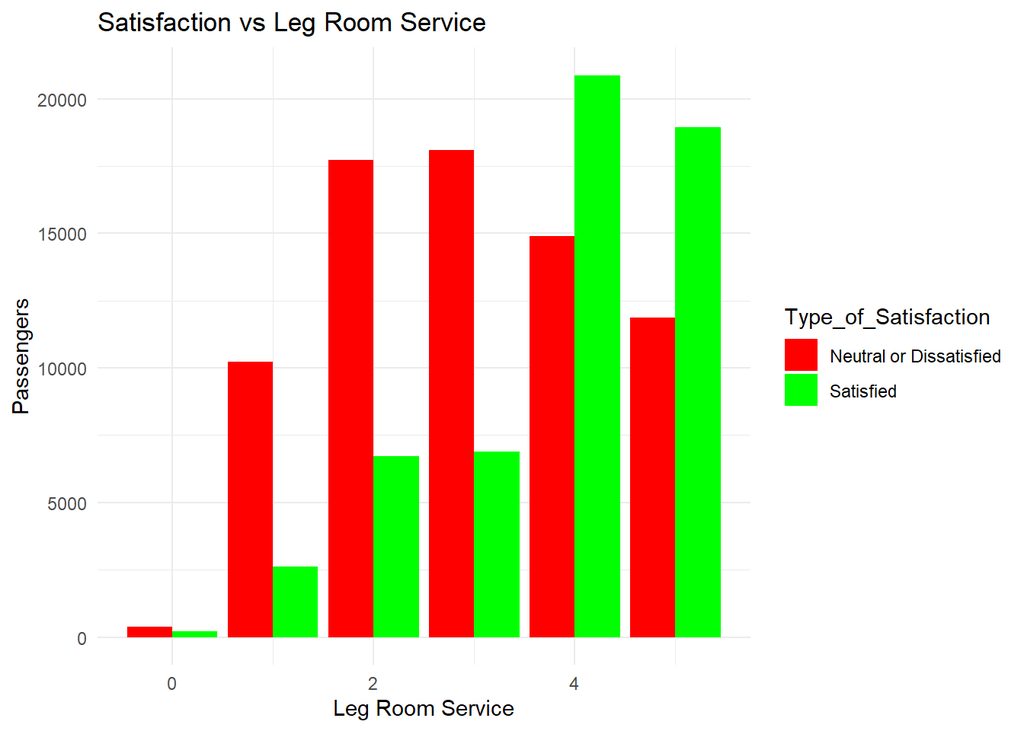

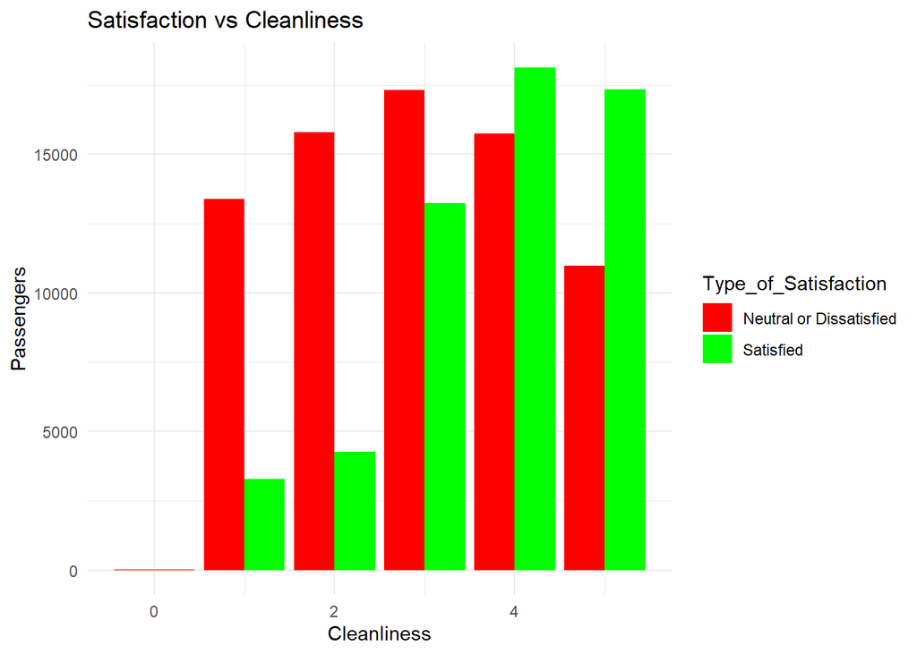

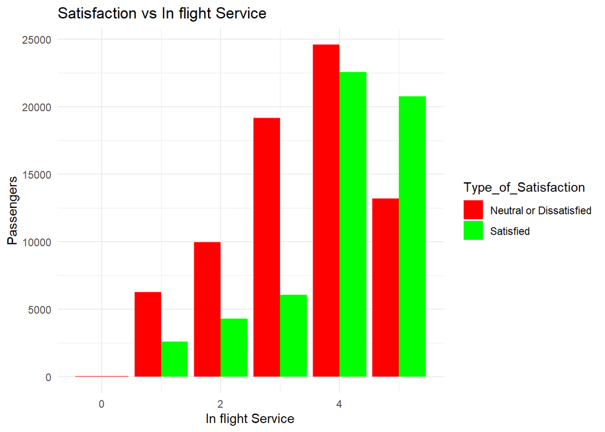

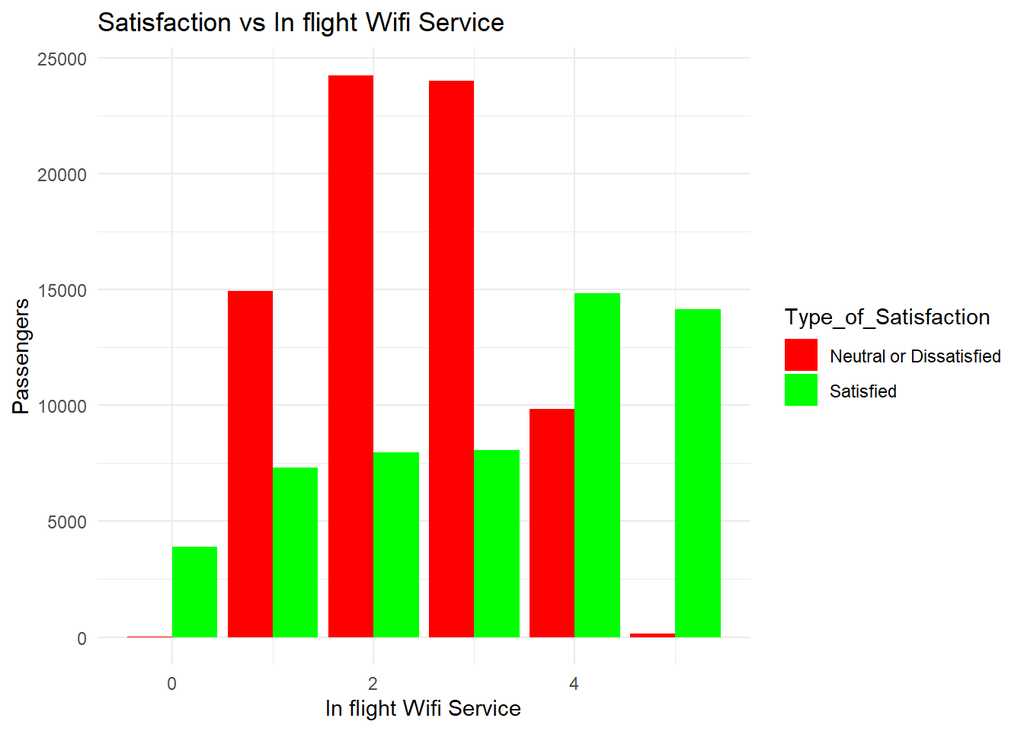

[1 more figures not shown]

It can be seen that for each category we always have satisfied and unsatisfied passengers, so using a single predictor is very difficult to predict customer satisfaction. It is necessary to evaluate which predictors are the most important in order to create a good model.

# 4 Logistic Regression

I first implement a logistic regression model using all predictors.

```r
model_with_all_predictors <- glm(Satisfaction ~ ., data = train, family = binomial)
summary(model_with_all_predictors)
```

```
##
## Call:
## glm(formula = Satisfaction ~ ., family = binomial, data = train)
##
## Coefficients:
##                                          Estimate Std. Error z value Pr(>|z|)
## (Intercept)                            -7.847e+00  7.877e-02 -99.616  < 2e-16
## GenderMale                              6.565e-02  1.946e-02   3.374 0.000741
## Age                                    -8.315e-03  7.109e-04 -11.697  < 2e-16
## Customer.TypeReturning                  2.031e+00  2.985e-02  68.043  < 2e-16
## Type.of.TravelPersonal                 -2.716e+00  3.141e-02 -86.481  < 2e-16
## ClassEconomy                           -7.127e-01  2.562e-02 -27.816  < 2e-16
## ClassEconomy Plus                      -8.083e-01  4.138e-02 -19.533  < 2e-16
## Flight.Distance                        -9.633e-06  1.127e-05  -0.855 0.392651
## Departure.and.Arrival.Time.Convenience -1.365e-01  8.184e-03 -16.676  < 2e-16
## Ease.of.Online.Booking                 -1.481e-01  1.129e-02 -13.116  < 2e-16
## Check.in.Service                        3.284e-01  8.553e-03  38.400  < 2e-16
## Online.Boarding                         6.105e-01  1.024e-02  59.646  < 2e-16
## Gate.Location                           2.552e-02  9.184e-03   2.779 0.005457
## On.board.Service                        2.929e-01  1.020e-02  28.714  < 2e-16
## Seat.Comfort                            6.539e-02  1.119e-02   5.843 5.14e-09
## Leg.Room.Service                        2.484e-01  8.521e-03  29.154  < 2e-16
## Cleanliness                             2.233e-01  1.209e-02  18.468  < 2e-16
## Food.and.Drink                         -2.977e-02  1.071e-02  -2.780 0.005439
## In.flight.Service                       1.166e-01  1.205e-02   9.677  < 2e-16
## In.flight.Wifi.Service                  4.031e-01  1.144e-02  35.228  < 2e-16
## In.flight.Entertainment                 6.215e-02  1.423e-02   4.367 1.26e-05
## Baggage.Handling                        1.484e-01  1.143e-02  12.987  < 2e-16
## Delay                                  -4.979e-03  2.684e-04 -18.546  < 2e-16
##
## (Intercept)                            ***
## GenderMale                             ***
## Age                                    ***
## Customer.TypeReturning                 ***
## Type.of.TravelPersonal                 ***
## ClassEconomy                           ***
## ClassEconomy Plus                      ***
## Flight.Distance
## Departure.and.Arrival.Time.Convenience ***
## Ease.of.Online.Booking                 ***
```

[output cut: 8 more lines]

```
## In.flight.Service                      ***
## In.flight.Wifi.Service                 ***
## In.flight.Entertainment                ***
## Baggage.Handling                       ***
## Delay                                  ***
## ---
## Signif. codes:  0 '***' 0.001 '**' 0.01 '*' 0.05 '.' 0.1 ' ' 1
##
## (Dispersion parameter for binomial family taken to be 1)
##
##     Null deviance: 141833  on 103611  degrees of freedom
## Residual deviance:  69400  on 103589  degrees of freedom
## AIC: 69446
##
## Number of Fisher Scoring iterations: 5
```

I run the logistic regression model with all predictors using cross validation.

```r
train_control <- trainControl(method = "cv", number = 10)  # 10-fold cross-validation

set.seed(123)

model_cv <- train(Satisfaction ~ ., data = train, method = "glm", family = "binomial", trControl = train_control)


print(model_cv)
```

```
## Generalized Linear Model
##
## 103612 samples
##     21 predictor
##      2 classes: '0', '1'
##
## No pre-processing
## Resampling: Cross-Validated (10 fold)
## Summary of sample sizes: 93250, 93251, 93251, 93251, 93251, 93251, ...
## Resampling results:
##
##   Accuracy   Kappa
##   0.8743003  0.7430011
```

```r
summary(model_cv$finalModel)
```

```
##
## Call:
## NULL
##
## Coefficients:
##                                          Estimate Std. Error z value Pr(>|z|)
## (Intercept)                            -7.847e+00  7.877e-02 -99.616  < 2e-16
## GenderMale                              6.565e-02  1.946e-02   3.374 0.000741
## Age                                    -8.315e-03  7.109e-04 -11.697  < 2e-16
## Customer.TypeReturning                  2.031e+00  2.985e-02  68.043  < 2e-16
## Type.of.TravelPersonal                 -2.716e+00  3.141e-02 -86.481  < 2e-16
## ClassEconomy                           -7.127e-01  2.562e-02 -27.816  < 2e-16
## `ClassEconomy Plus`                    -8.083e-01  4.138e-02 -19.533  < 2e-16
## Flight.Distance                        -9.633e-06  1.127e-05  -0.855 0.392651
## Departure.and.Arrival.Time.Convenience -1.365e-01  8.184e-03 -16.676  < 2e-16
## Ease.of.Online.Booking                 -1.481e-01  1.129e-02 -13.116  < 2e-16
## Check.in.Service                        3.284e-01  8.553e-03  38.400  < 2e-16
## Online.Boarding                         6.105e-01  1.024e-02  59.646  < 2e-16
## Gate.Location                           2.552e-02  9.184e-03   2.779 0.005457
## On.board.Service                        2.929e-01  1.020e-02  28.714  < 2e-16
## Seat.Comfort                            6.539e-02  1.119e-02   5.843 5.14e-09
## Leg.Room.Service                        2.484e-01  8.521e-03  29.154  < 2e-16
## Cleanliness                             2.233e-01  1.209e-02  18.468  < 2e-16
## Food.and.Drink                         -2.977e-02  1.071e-02  -2.780 0.005439
## In.flight.Service                       1.166e-01  1.205e-02   9.677  < 2e-16
## In.flight.Wifi.Service                  4.031e-01  1.144e-02  35.228  < 2e-16
## In.flight.Entertainment                 6.215e-02  1.423e-02   4.367 1.26e-05
## Baggage.Handling                        1.484e-01  1.143e-02  12.987  < 2e-16
## Delay                                  -4.979e-03  2.684e-04 -18.546  < 2e-16
##
## (Intercept)                            ***
## GenderMale                             ***
## Age                                    ***
## Customer.TypeReturning                 ***
## Type.of.TravelPersonal                 ***
## ClassEconomy                           ***
## `ClassEconomy Plus`                    ***
## Flight.Distance
## Departure.and.Arrival.Time.Convenience ***
## Ease.of.Online.Booking                 ***
```

[output cut: 8 more lines]

```
## In.flight.Service                      ***
## In.flight.Wifi.Service                 ***
## In.flight.Entertainment                ***
## Baggage.Handling                       ***
## Delay                                  ***
## ---
## Signif. codes:  0 '***' 0.001 '**' 0.01 '*' 0.05 '.' 0.1 ' ' 1
##
## (Dispersion parameter for binomial family taken to be 1)
##
##     Null deviance: 141833  on 103611  degrees of freedom
## Residual deviance:  69400  on 103589  degrees of freedom
## AIC: 69446
##
## Number of Fisher Scoring iterations: 5
```

We can see that most of the predictors are important for the model except at Flight Distance. Two other less important predictors are Gate Location and Food&Drink. This model performs very well using all predictors.

What I will do in the next chapters is to create simpler models using fewer predictors.

# 5 Features selection

After a thorough analysis, I merged the categories of the dataset into different classes in order to perform a more precise feature selection. Each set groups the most similar categories. This grouping was done in order to interpret the categories more easily. Here are the following classes:

- `Customer and Travel Type`: Customer.Type, Type.of.Travel, Class.
- `Time and Distance`: Flight.Distance, Delay.
- `Convenience and Booking Services`: Departure.and.Arrival.Time.Convenience, Ease.of.Online.Booking.
- `On-board Services`: Food.and.Drink, In.flight.Service, In.flight.Wifi.Service, In.flight.Entertainment.
- `Comfort and Cleanliness`: Seat.Comfort, Leg.Room.Service, Cleanliness.
- `Airport Services`: Gate.Location, On.board.Service, Baggage.Handling, Check.in.Service, Online.Boarding.
- `Demographic variables`: Age.

The first objective is to see which set of services leads to a better prediction of passenger satisfaction. Using all predictors certainly leads to a very good result, but by using precise categories, is it still possible to understand whether customers are satisfied or dissatisfied?

Next I go and create a model for each class listed above. Then I calculate the following values: AIC, AUC to see which model is better. Finally, for each model, I run a test with two different threshold values: 0.5 and the best threshold, then I perform inference on some variables to see how the probability of passenger satisfaction changes.

At the end of the chapter there is a summary table with all the results.

## 5.1 Customer and Travel Type Model

This model analyses the type of passenger, the class used and the type of journey (whether business or holiday).

```r
Customer_and_Travel_Type_model <- glm(Satisfaction ~ Customer.Type + Type.of.Travel + Class, data = train, family = binomial)

summary(Customer_and_Travel_Type_model)
```

```
##
## Call:
## glm(formula = Satisfaction ~ Customer.Type + Type.of.Travel +
##     Class, family = binomial, data = train)
##
## Coefficients:
##                        Estimate Std. Error z value Pr(>|z|)
## (Intercept)            -0.48671    0.01951  -24.95   <2e-16 ***
## Customer.TypeReturning  1.72002    0.02062   83.41   <2e-16 ***
## Type.of.TravelPersonal -2.28550    0.02338  -97.74   <2e-16 ***
## ClassEconomy           -1.24449    0.01844  -67.49   <2e-16 ***
## ClassEconomy Plus      -1.39400    0.03164  -44.06   <2e-16 ***
## ---
## Signif. codes:  0 '***' 0.001 '**' 0.01 '*' 0.05 '.' 0.1 ' ' 1
##
## (Dispersion parameter for binomial family taken to be 1)
##
##     Null deviance: 141833  on 103611  degrees of freedom
## Residual deviance: 100240  on 103607  degrees of freedom
## AIC: 100250
##
## Number of Fisher Scoring iterations: 4
```

Below the execution of the test set with the current model:

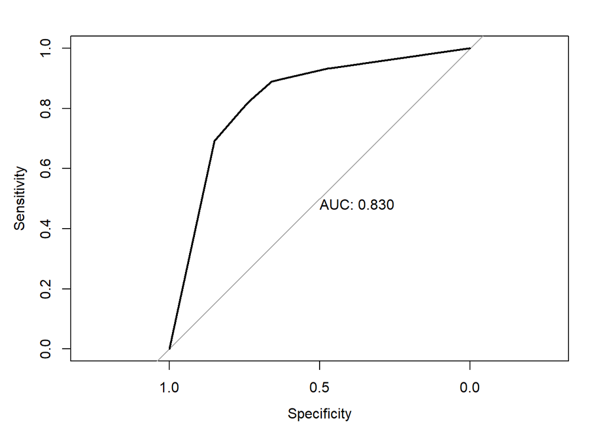

```r
Customer_and_Travel_Type_model_probs <- predict(Customer_and_Travel_Type_model, testX, type = "response")

Customer_and_Travel_Type_model_roc <- roc(test$Satisfaction ~ Customer_and_Travel_Type_model_probs, plot=TRUE, print.auc=TRUE)
```

Returns all information for the classification threshold of 0.5.

```r
coords(Customer_and_Travel_Type_model_roc, x=0.5, ret="all")
```

```
##           threshold specificity sensitivity  accuracy    tn   tp   fn   fp
## threshold       0.5   0.8492531   0.6919599 0.7806763 12394 7806 3475 2200
##                 npv       ppv       fdr       fpr       tpr       tnr       fnr
## threshold 0.7810196 0.7801319 0.2198681 0.1507469 0.6919599 0.8492531 0.3080401
##           1-specificity 1-sensitivity 1-accuracy     1-npv     1-ppv precision
## threshold     0.1507469     0.3080401  0.2193237 0.2189804 0.2198681 0.7801319
##              recall   youden closest.topleft
## threshold 0.6919599 1.541213       0.1176133
```

Returns all information for the classification usign the best threshold.

```r
coords(Customer_and_Travel_Type_model_roc, x="best", ret="all")
```

```
##           threshold specificity sensitivity  accuracy    tn   tp   fn   fp
## threshold 0.4202905   0.7353022   0.8232426 0.7736425 10731 9287 1994 3863
##                 npv       ppv       fdr       fpr       tpr       tnr       fnr
## threshold 0.8433006 0.7062357 0.2937643 0.2646978 0.8232426 0.7353022 0.1767574
##           1-specificity 1-sensitivity 1-accuracy     1-npv     1-ppv precision
## threshold     0.2646978     0.1767574  0.2263575 0.1566994 0.2937643 0.7062357
##              recall   youden closest.topleft
## threshold 0.8232426 1.558545       0.1013081
```

Check the collinearity between predictors in a regression model. Collinearity occurs when two or more predictors in a model are highly correlated.

```r
check_collinearity <- vif(Customer_and_Travel_Type_model)
check_collinearity
```

```
##                   GVIF Df GVIF^(1/(2*Df))
## Customer.Type  1.08858  1        1.043351
## Type.of.Travel 1.28415  1        1.133204
## Class          1.23038  2        1.053197
```

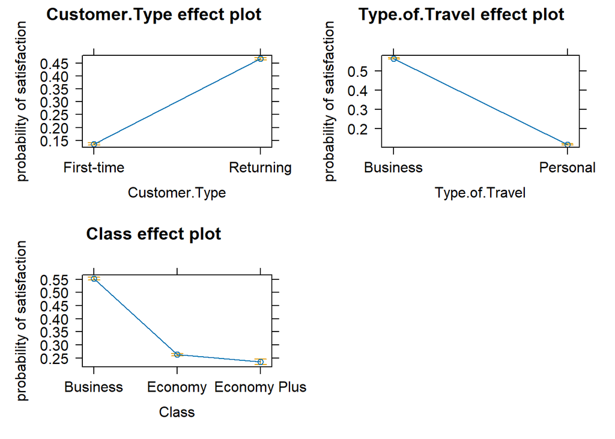

```r
plot(allEffects(Customer_and_Travel_Type_model), ylab="probability of satisfaction", rescale.axis=FALSE)
```

From the plots we can see these categories affect passenger satisfaction. We are now going to perform inference by looking at how the class of the passenger may favour satisfaction. Let us take an example of a business class passenger and first downgrade him/her to economy plus and then to economy.

```r
testX[12,]
```

```
##    Gender Age Customer.Type Type.of.Travel    Class Flight.Distance
## 59 Female  41     Returning       Business Business            3997
##    Departure.and.Arrival.Time.Convenience Ease.of.Online.Booking
## 59                                      1                      1
##    Check.in.Service Online.Boarding Gate.Location On.board.Service Seat.Comfort
## 59                5               4             1                4            5
##    Leg.Room.Service Cleanliness Food.and.Drink In.flight.Service
## 59                4           4              4                 4
##    In.flight.Wifi.Service In.flight.Entertainment Baggage.Handling Delay
## 59                      1                       4                5   0.5
```

```r
test12<-testX[12,]
pred1.probs <- predict(Customer_and_Travel_Type_model, test12, type = "response")
pred1.probs
```

```
##        59
## 0.7743967
```

```r
i1 <- predict(Customer_and_Travel_Type_model, test12, type = "response", se.fit = TRUE)
lo1 <- i1$fit - qnorm(0.975) * i1$se
up1 <- i1$fit + qnorm(0.975) * i1$se
c(lo1, up1)
```

```
##        59        59
## 0.7705258 0.7782675
```

From business to economy plus

```r
test12$Class<-"Economy Plus"
pred2.probs <- predict(Customer_and_Travel_Type_model, test12, type = "response")
pred2.probs
```

```
##        59
## 0.4599121
```

```r
i2 <- predict(Customer_and_Travel_Type_model, test12, type = "response", se.fit = TRUE)
lo2 <- i2$fit - qnorm(0.975) * i2$se
up2 <- i2$fit + qnorm(0.975) * i2$se
c(lo2, up2)
```

```
##        59        59
## 0.4452381 0.4745861
```

From economy plus to economy

```r
test12$Class<-"Economy"
pred3.probs <- predict(Customer_and_Travel_Type_model, test12, type = "response")
pred3.probs
```

```
##        59
## 0.4972042
```

```r
i3 <- predict(Customer_and_Travel_Type_model, test12, type = "response", se.fit = TRUE)
lo3 <- i3$fit - qnorm(0.975) * i3$se
up3 <- i3$fit + qnorm(0.975) * i3$se
c(lo3, up3)
```

```
##        59        59
## 0.4888826 0.5055257
```

What can be seen remains in line with the plot seen above. The probability of satisfaction of a person in business class is high. If moved to Economy plus it decreases dramatically and if moved to economy it increases slightly compared to the previous class but still the probability of being satisfied is low.

We can conclude that this model is the only one that uses categorical variables and as can be seen above changing from a higher to a lower class decreases the probability of being satisfied. We can also note that satisfaction is affected by the type of travel. Travelling business class for business is more satisfying than travelling in the same class for personal purposes. Travelling economy class, on the other hand, is not satisfying in most cases.

## 5.2 Time and Distance Model

This model calculates passenger satisfaction conditioned by flight distance and possible delays.

```r
Time_and_Distance_model <- glm(Satisfaction ~ Flight.Distance + Delay, data = train, family = binomial)

summary(Time_and_Distance_model)
```

```
##
## Call:
## glm(formula = Satisfaction ~ Flight.Distance + Delay, family = binomial,
##     data = train)
##
## Coefficients:
##                   Estimate Std. Error z value Pr(>|z|)
## (Intercept)     -9.870e-01  1.080e-02  -91.41   <2e-16 ***
## Flight.Distance  6.447e-04  7.009e-06   91.99   <2e-16 ***
## Delay           -3.432e-03  1.967e-04  -17.45   <2e-16 ***
## ---
## Signif. codes:  0 '***' 0.001 '**' 0.01 '*' 0.05 '.' 0.1 ' ' 1
##
## (Dispersion parameter for binomial family taken to be 1)
##
##     Null deviance: 141833  on 103611  degrees of freedom
## Residual deviance: 131978  on 103609  degrees of freedom
## AIC: 131984
##
## Number of Fisher Scoring iterations: 4
```

Below the execution of the test set with the current model:

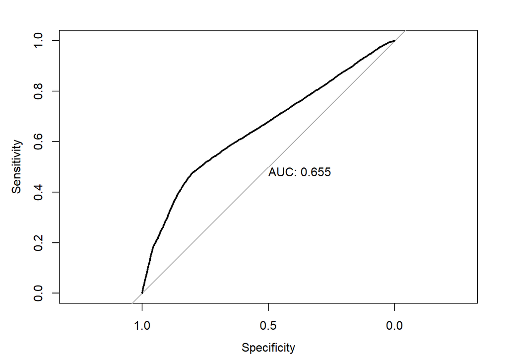

```r
Time_and_Distance_model_probs <- predict(Time_and_Distance_model, testX, type = "response")

Time_and_Distance_model_roc <- roc(test$Satisfaction ~ Time_and_Distance_model_probs, plot=TRUE, print.auc=TRUE)
```

Returns all information for the classification threshold of 0.5.

```r
coords(Time_and_Distance_model_roc, x=0.5, ret="all")
```

```
##           threshold specificity sensitivity  accuracy    tn   tp   fn   fp
## threshold       0.5   0.8335617   0.4332949 0.6590531 12165 4888 6393 2429
##                 npv       ppv       fdr       fpr       tpr       tnr       fnr
## threshold 0.6555124 0.6680333 0.3319667 0.1664383 0.4332949 0.8335617 0.5667051
##           1-specificity 1-sensitivity 1-accuracy     1-npv     1-ppv precision
## threshold     0.1664383     0.5667051  0.3409469 0.3444876 0.3319667 0.6680333
##              recall   youden closest.topleft
## threshold 0.4332949 1.266857       0.3488563
```

Returns all information for the classification usign the best threshold.

```r
coords(Time_and_Distance_model_roc, x="best", ret="all")
```

```
##           threshold specificity sensitivity  accuracy    tn   tp   fn   fp
## threshold 0.4722063   0.8038235   0.4736282 0.6598647 11731 5343 5938 2863
##                 npv       ppv       fdr       fpr       tpr       tnr       fnr
## threshold 0.6639312 0.6511089 0.3488911 0.1961765 0.4736282 0.8038235 0.5263718
##           1-specificity 1-sensitivity 1-accuracy     1-npv     1-ppv precision
## threshold     0.1961765     0.5263718  0.3401353 0.3360688 0.3488911 0.6511089
##              recall   youden closest.topleft
## threshold 0.4736282 1.277452       0.3155525
```

Check the collinearity between predictors in a regression model. Collinearity occurs when two or more predictors in a model are highly correlated.

```r
check_collinearity <- vif(Time_and_Distance_model)
check_collinearity
```

```
## Flight.Distance           Delay
##        1.001019        1.001019
```

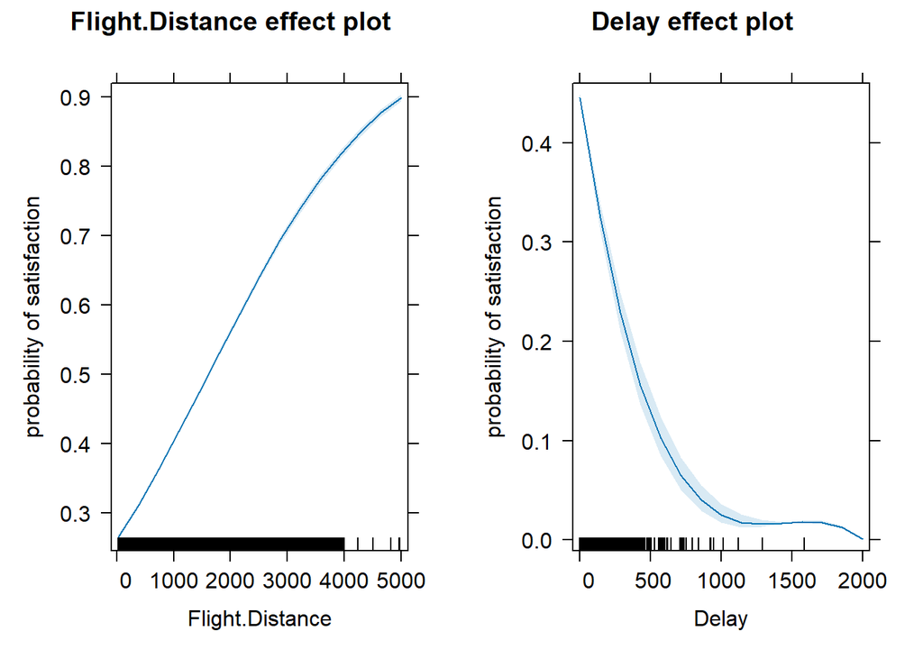

```r
plot(allEffects(Time_and_Distance_model), ylab="probability of satisfaction", rescale.axis=FALSE)
```

Next, let us analyse a test example and change the delay time to see how the probability of being satisfied changes.

```r
testX[12,]
```

```
##    Gender Age Customer.Type Type.of.Travel    Class Flight.Distance
## 59 Female  41     Returning       Business Business            3997
##    Departure.and.Arrival.Time.Convenience Ease.of.Online.Booking
## 59                                      1                      1
##    Check.in.Service Online.Boarding Gate.Location On.board.Service Seat.Comfort
## 59                5               4             1                4            5
##    Leg.Room.Service Cleanliness Food.and.Drink In.flight.Service
## 59                4           4              4                 4
##    In.flight.Wifi.Service In.flight.Entertainment Baggage.Handling Delay
## 59                      1                       4                5   0.5
```

```r
line12<-testX[12,]
pred1.probs <- predict(Time_and_Distance_model, line12, type = "response")
pred1.probs
```

```
##       59
## 0.830353
```

```r
i1 <- predict(Time_and_Distance_model, line12, type = "response", se.fit = TRUE)
lo1 <- i1$fit - qnorm(0.975) * i1$se
up1 <- i1$fit + qnorm(0.975) * i1$se
c(lo1, up1)
```

```
##       59       59
## 0.824525 0.836181
```

Add delay of 4 hours

```r
line12$Delay<-240
pred2.probs <- predict(Time_and_Distance_model, line12, type = "response")
pred2.probs
```

```
##        59
## 0.6826935
```

An increase in the delay of a flight decreases the probability of being satisfied; conversely, an increase in distance leads to greater passenger satisfaction.

## 5.3 Convenience and Booking Services Model

This model calculates passenger satisfaction based on ease of buying travel and choice of departure and arrival times.

```r
Convenience_and_Booking_Services_model <- glm(Satisfaction ~ Departure.and.Arrival.Time.Convenience + Ease.of.Online.Booking, data = train, family = binomial)

summary(Convenience_and_Booking_Services_model)
```

```
##
## Call:
## glm(formula = Satisfaction ~ Departure.and.Arrival.Time.Convenience +
##     Ease.of.Online.Booking, family = binomial, data = train)
##
## Coefficients:
##                                         Estimate Std. Error z value Pr(>|z|)
## (Intercept)                            -0.589453   0.016312  -36.14   <2e-16
## Departure.and.Arrival.Time.Convenience -0.233652   0.004980  -46.92   <2e-16
## Ease.of.Online.Booking                  0.371566   0.005487   67.72   <2e-16
##
## (Intercept)                            ***
## Departure.and.Arrival.Time.Convenience ***
## Ease.of.Online.Booking                 ***
## ---
## Signif. codes:  0 '***' 0.001 '**' 0.01 '*' 0.05 '.' 0.1 ' ' 1
##
## (Dispersion parameter for binomial family taken to be 1)
##
##     Null deviance: 141833  on 103611  degrees of freedom
## Residual deviance: 136504  on 103609  degrees of freedom
## AIC: 136510
##
## Number of Fisher Scoring iterations: 4
```

Below the execution of the test set with the current model:

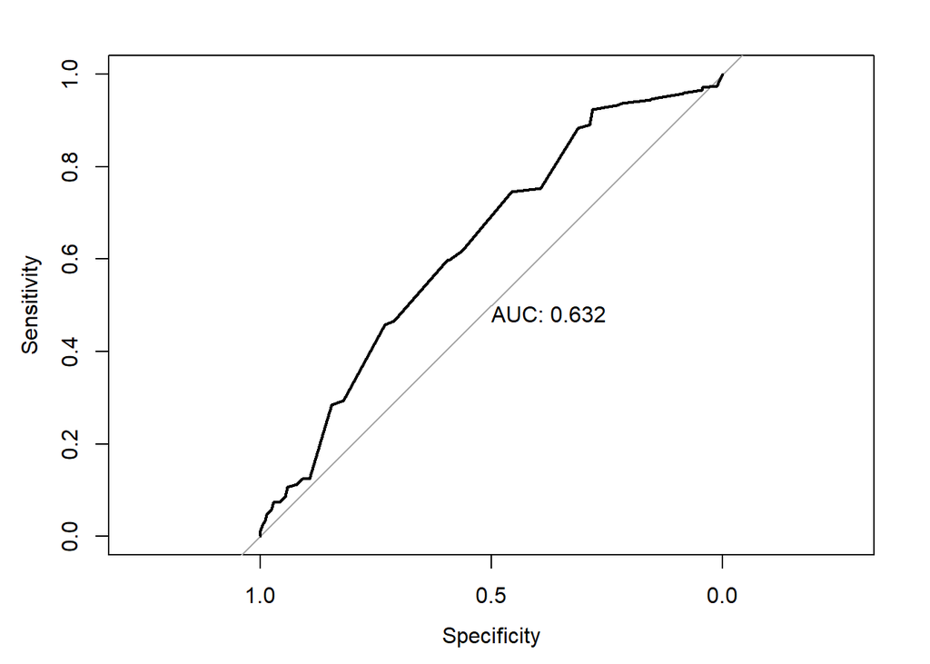

```r
Convenience_and_Booking_Services_model_probs <- predict(Convenience_and_Booking_Services_model, testX, type = "response")

Convenience_and_Booking_Services_model_roc <- roc(test$Satisfaction ~ Convenience_and_Booking_Services_model_probs, plot=TRUE, print.auc=TRUE)
```

Returns all information for the classification threshold of 0.5.

```r
coords(Convenience_and_Booking_Services_model_roc, x=0.5, ret="all")
```

```
##           threshold specificity sensitivity  accuracy    tn   tp   fn   fp
## threshold       0.5   0.8205427   0.2939456 0.5909565 11975 3316 7965 2619
##                 npv       ppv       fdr       fpr       tpr       tnr       fnr
## threshold 0.6005517 0.5587195 0.4412805 0.1794573 0.2939456 0.8205427 0.7060544
##           1-specificity 1-sensitivity 1-accuracy     1-npv     1-ppv precision
## threshold     0.1794573     0.7060544  0.4090435 0.3994483 0.4412805 0.5587195
##              recall   youden closest.topleft
## threshold 0.2939456 1.114488       0.5307178
```

Returns all information for the classification usign the best threshold.

```r
coords(Convenience_and_Booking_Services_model_roc, x="best", ret="all")
```

```
##           threshold specificity sensitivity  accuracy   tn    tp  fn    fp
## threshold 0.3506629   0.2816911   0.9239429 0.5617005 4111 10423 858 10483
##                 npv      ppv      fdr       fpr       tpr       tnr        fnr
## threshold 0.8273294 0.498565 0.501435 0.7183089 0.9239429 0.2816911 0.07605709
##           1-specificity 1-sensitivity 1-accuracy     1-npv    1-ppv precision
## threshold     0.7183089    0.07605709  0.4382995 0.1726706 0.501435  0.498565
##              recall   youden closest.topleft
## threshold 0.9239429 1.205634       0.5217523
```

Check the collinearity between predictors in a regression model. Collinearity occurs when two or more predictors in a model are highly correlated.

```r
check_collinearity <- vif(Convenience_and_Booking_Services_model)
check_collinearity
```

```
## Departure.and.Arrival.Time.Convenience                 Ease.of.Online.Booking
##                               1.370973                               1.370973
```

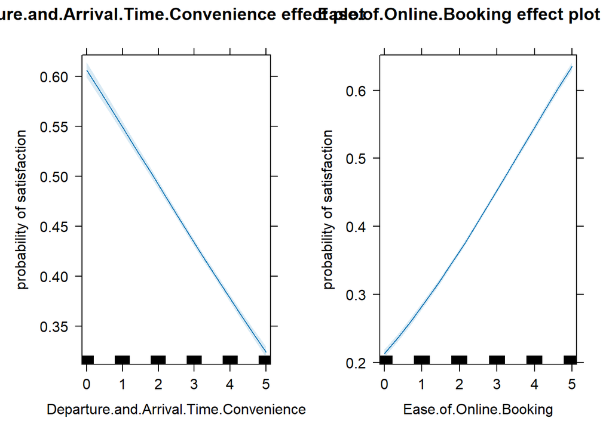

```r
plot(allEffects(Convenience_and_Booking_Services_model), ylab="probability of satisfaction", rescale.axis=FALSE)
```

Let us perform some inference to see how the probability of being satisfied changes.

```r
testX[12,]
```

```
##    Gender Age Customer.Type Type.of.Travel    Class Flight.Distance
## 59 Female  41     Returning       Business Business            3997
##    Departure.and.Arrival.Time.Convenience Ease.of.Online.Booking
## 59                                      1                      1
##    Check.in.Service Online.Boarding Gate.Location On.board.Service Seat.Comfort
## 59                5               4             1                4            5
##    Leg.Room.Service Cleanliness Food.and.Drink In.flight.Service
## 59                4           4              4                 4
##    In.flight.Wifi.Service In.flight.Entertainment Baggage.Handling Delay
## 59                      1                       4                5   0.5
```

```r
test12<-testX[12,]
pred1.probs <- predict(Convenience_and_Booking_Services_model, test12, type = "response")
pred1.probs
```

```
##        59
## 0.3889949
```

```r
i1 <- predict(Convenience_and_Booking_Services_model, test12, type = "response", se.fit = TRUE)
lo1 <- i1$fit - qnorm(0.975) * i1$se
up1 <- i1$fit + qnorm(0.975) * i1$se
c(lo1, up1)
```

```
##        59        59
## 0.3835108 0.3944790
```

```r
test12$Departure.and.Arrival.Time.Convenience<-5
pred2.probs <- predict(Convenience_and_Booking_Services_model, test12, type = "response")
pred2.probs
```

```
##        59
## 0.2000236
```

```r
i2 <- predict(Convenience_and_Booking_Services_model, test12, type = "response", se.fit = TRUE)
lo2 <- i2$fit - qnorm(0.975) * i2$se
up2 <- i2$fit + qnorm(0.975) * i2$se
c(lo2, up2)
```

```
##        59        59
## 0.1942489 0.2057983
```

```r
test12$Ease.of.Online.Booking<-5
pred3.probs <- predict(Convenience_and_Booking_Services_model, test12, type = "response")
pred3.probs
```

```
##        59
## 0.5250084
```

```r
i3 <- predict(Convenience_and_Booking_Services_model, test12, type = "response", se.fit = TRUE)
lo3 <- i3$fit - qnorm(0.975) * i3$se
up3 <- i3$fit + qnorm(0.975) * i3$se
c(lo3, up3)
```

```
##        59        59
## 0.5188604 0.5311565
```

Here again we can see how increasing or decreasing the values leads to a change in probability. If changed individually there is an elevated change if together the result balances out.